# GoldSpotPrediction_01

```python
import pandas as pd
import numpy as np
import matplotlib.pyplot as plt
```

## EDA (not sure if byby already done this)

```python
df = pd.read_csv("../data/goldstock v2.csv")
```

```python
df.head()
```

|  | Unnamed: 0 | Date | Close/Last | Volume | Open | High | Low |
| --- | --- | --- | --- | --- | --- | --- | --- |
| 0 | 0 | 2024-07-03 | 2369.4 | 185930.0 | 2338.6 | 2374.5 | 2335.7 |
| 1 | 1 | 2024-07-02 | 2333.4 | 146568.0 | 2341.6 | 2346.1 | 2327.4 |
| 2 | 2 | 2024-07-01 | 2338.9 | 136861.0 | 2336.2 | 2348.8 | 2328.2 |
| 3 | 3 | 2024-06-28 | 2339.6 | 131191.0 | 2338.6 | 2350.6 | 2329.7 |
| 4 | 4 | 2024-06-27 | 2336.6 | 135784.0 | 2309.4 | 2342.0 | 2306.8 |

```python
print(df.columns)
```

```
Index(['Unnamed: 0', 'Date', 'Close/Last', 'Volume', 'Open', 'High', 'Low'], dtype='object')
```

```python
df = df.drop(columns=['Unnamed: 0'])
```

```python
df.head()
```

|  | Date | Close/Last | Volume | Open | High | Low |
| --- | --- | --- | --- | --- | --- | --- |
| 0 | 2024-07-03 | 2369.4 | 185930.0 | 2338.6 | 2374.5 | 2335.7 |
| 1 | 2024-07-02 | 2333.4 | 146568.0 | 2341.6 | 2346.1 | 2327.4 |
| 2 | 2024-07-01 | 2338.9 | 136861.0 | 2336.2 | 2348.8 | 2328.2 |
| 3 | 2024-06-28 | 2339.6 | 131191.0 | 2338.6 | 2350.6 | 2329.7 |
| 4 | 2024-06-27 | 2336.6 | 135784.0 | 2309.4 | 2342.0 | 2306.8 |

```python
df['Date'] = pd.to_datetime(df['Date'])
```

```python
#Sort date chronologically

df = df.sort_values('Date')
df = df.reset_index(drop=True)
```

```python
df.head()
```

|  | Date | Close/Last | Volume | Open | High | Low |
| --- | --- | --- | --- | --- | --- | --- |
| 0 | 2014-07-07 | 1317.0 | 79110.0 | 1321.4 | 1321.7 | 1312.1 |
| 1 | 2014-07-08 | 1316.5 | 126706.0 | 1320.8 | 1325.7 | 1314.3 |
| 2 | 2014-07-09 | 1324.3 | 155101.0 | 1320.4 | 1333.4 | 1318.7 |
| 3 | 2014-07-10 | 1339.2 | 167391.0 | 1325.0 | 1346.8 | 1325.0 |
| 4 | 2014-07-11 | 1337.4 | 88470.0 | 1336.5 | 1340.4 | 1334.6 |

Plot the gold

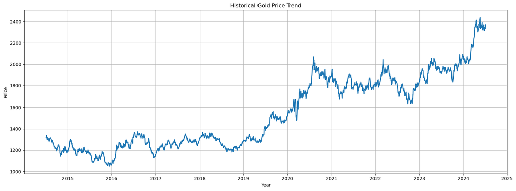

```python
plt.figure(figsize=(16,6))

plt.plot(
    df['Date'],
    df['Close/Last'],
    linewidth=2
)

plt.title("Historical Gold Price Trend")

plt.xlabel("Year")

plt.ylabel("Price")

plt.grid()

plt.tight_layout()

plt.show()
```

## Volatile segmentation

- Volatility should usually be based on returns, not raw prices.
- Volatility measures how much returns fluctuate.

```python
#calculate returns

df['returns'] = df['Close/Last'].pct_change()
```

```python
df['volatility'] = df['returns'].rolling(
    window=10
).std()
```

```python
#There are many NaN for the first 10 days, because there isn't any data to refer for the initial 10 days.

df[['Date','Close/Last','volatility']].head(35)
```

|  | Date | Close/Last | volatility |
| --- | --- | --- | --- |
| 0 | 2014-07-07 | 1317.0 | NaN |
| 1 | 2014-07-08 | 1316.5 | NaN |
| 2 | 2014-07-09 | 1324.3 | NaN |
| 3 | 2014-07-10 | 1339.2 | NaN |
| 4 | 2014-07-11 | 1337.4 | NaN |
| 5 | 2014-07-14 | 1306.7 | NaN |
| 6 | 2014-07-15 | 1297.1 | NaN |
| 7 | 2014-07-16 | 1299.8 | NaN |
| 8 | 2014-07-17 | 1316.9 | NaN |
| 9 | 2014-07-18 | 1309.4 | NaN |
| 10 | 2014-07-21 | 1315.5 | 0.010414 |
| 11 | 2014-07-22 | 1308.0 | 0.010567 |
| 12 | 2014-07-23 | 1306.5 | 0.010315 |
| 13 | 2014-07-24 | 1292.7 | 0.009650 |
| 14 | 2014-07-25 | 1305.3 | 0.010522 |
| 15 | 2014-07-28 | 1305.8 | 0.007645 |
| 16 | 2014-07-29 | 1300.5 | 0.007362 |
| 17 | 2014-07-30 | 1296.9 | 0.007390 |
| 18 | 2014-07-31 | 1282.8 | 0.006406 |
| 19 | 2014-08-01 | 1294.8 | 0.007303 |
| 20 | 2014-08-04 | 1288.9 | 0.007074 |
| 21 | 2014-08-05 | 1285.3 | 0.006965 |
| 22 | 2014-08-06 | 1308.2 | 0.009323 |
| 23 | 2014-08-07 | 1312.5 | 0.008548 |
| 24 | 2014-08-08 | 1311.0 | 0.008069 |
| 25 | 2014-08-11 | 1310.5 | 0.008073 |
| 26 | 2014-08-12 | 1310.6 | 0.007925 |
| 27 | 2014-08-13 | 1314.5 | 0.007845 |
| 28 | 2014-08-14 | 1315.7 | 0.006584 |
| 29 | 2014-08-15 | 1306.2 | 0.006766 |
| 30 | 2014-08-18 | 1299.3 | 0.006835 |
| 31 | 2014-08-19 | 1296.7 | 0.006793 |
| 32 | 2014-08-20 | 1295.2 | 0.003291 |
| 33 | 2014-08-21 | 1275.4 | 0.005259 |
| 34 | 2014-08-22 | 1280.2 | 0.005651 |

Compute Threshold

```python
#This calculates the volatility cut off point

vol_mean = df['volatility'].mean()
vol_std = df['volatility'].std()

threshold = vol_mean + 2*vol_std

print(threshold)
```

```
0.01590992114867454
```

Categorize the Regimes (Stable, Volatile)

```python
df['regime'] = np.where(
    df['volatility'] > threshold,
    'volatile',
    'stable'
)
```

```python
df[['Date','volatility','regime']].tail()
```

|  | Date | volatility | regime |
| --- | --- | --- | --- |
| 2506 | 2024-06-27 | 0.011154 | stable |
| 2507 | 2024-06-28 | 0.009848 | stable |
| 2508 | 2024-07-01 | 0.008824 | stable |
| 2509 | 2024-07-02 | 0.008394 | stable |
| 2510 | 2024-07-03 | 0.009450 | stable |

```python
df['regime'].value_counts()
```

```
regime
stable      2406
volatile     105
Name: count, dtype: int64
```

Plot Volatility and the Threshold

- The high spikes might indicate major events, causes high volatility.

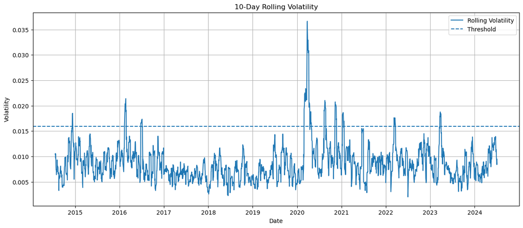

```python
plt.figure(figsize=(15,6))

plt.plot(
    df['Date'],
    df['volatility'],
    label='Rolling Volatility'
)

plt.axhline(
    threshold,
    linestyle='--',
    label='Threshold'
)

plt.title(
    "10-Day Rolling Volatility"
)

plt.xlabel("Date")
plt.ylabel("Volatility")

plt.legend()

plt.grid()

plt.show()
```

Plot Stable vs Volatile Periods

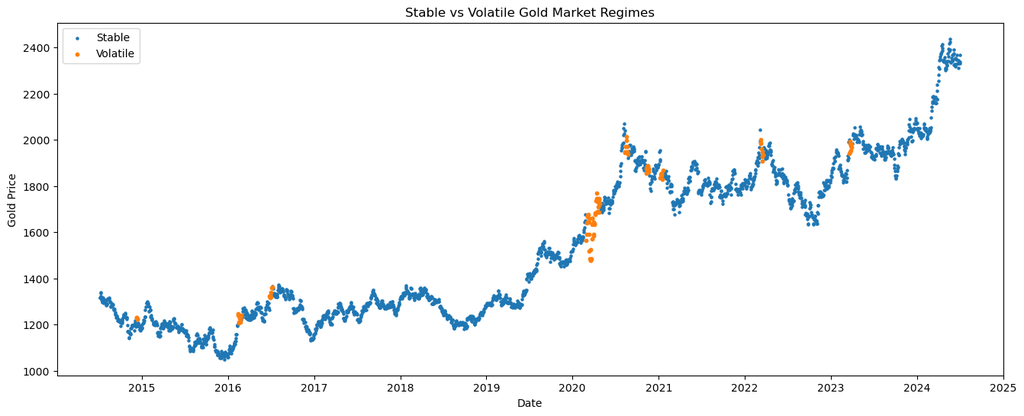

```python
plt.figure(figsize=(16,6))

stable = df[df['regime']=='stable']

volatile = df[df['regime']=='volatile']

plt.scatter(
    stable['Date'],
    stable['Close/Last'],
    s=5,
    label='Stable'
)

plt.scatter(
    volatile['Date'],
    volatile['Close/Last'],
    s=10,
    label='Volatile'
)

plt.title(
    'Stable vs Volatile Gold Market Regimes'
)

plt.xlabel("Date")

plt.ylabel("Gold Price")

plt.legend()

plt.show()
```

## Model Comparison Methodology

- Vanilla, Informer, TFT

For each model, we compare within the same regimes, then across different regimes, using evaluation metrics MAE, MSE, R squared.

```python
#Split dataset by regime

stable_df = df[df['regime']=="stable"].copy()

volatile_df = df[df['regime']=="volatile"].copy()

print(len(stable_df))
print(len(volatile_df))
```

```
2406
105
```

## Prepare train and test dataset

```python
# Train/test split, cannot use random split, since df is time series, need to be chronological.

def chronological_split(data):

    split_idx=int(len(data)*0.8)

    train=data[:split_idx]
    test=data[split_idx:]

    return train,test
```

```python
stable_train,stable_test=chronological_split(
    stable_df
)

volatile_train,volatile_test=chronological_split(
    volatile_df
)
```

Scale the data (normalize data from 0 to 1) for more stable transformer training

- Currently only using single variable input (Closing price), so essentially using past close prices to predict the next close price.
- Will progress into multivariate inputs if possible (Open + High + Low + Close + Volume).

```python
from sklearn.preprocessing import MinMaxScaler

scaler=MinMaxScaler()
```

Scale Stable regime

```python
stable_train_close=scaler.fit_transform(
    stable_train[['Close/Last']]
)

stable_test_close=scaler.transform(
    stable_test[['Close/Last']]
)
```

Scale Volatile regime

```python
volatile_train_close = scaler.fit_transform(
    volatile_train[['Close/Last']]
)

volatile_test_close = scaler.transform(
    volatile_test[['Close/Last']]
)
```

Transformers need windows, they do not read one value at a time.

- using the past 10 days, to predict the next day

```python
#Create the helper for 10 day window

def create_sequences(data,seq_len=10):

    X=[]

    y=[]

    for i in range(len(data)-seq_len):

        X.append(
            data[i:i+seq_len]
        )

        y.append(
            data[i+seq_len]
        )

    return np.array(X),np.array(y)
```

Window for Stable regime

```python
X_stable_train,y_stable_train = create_sequences(
    stable_train_close
)

X_stable_test,y_stable_test = create_sequences(
    stable_test_close
)
```

Window for Volatile regime

```python
X_volatile_train,y_volatile_train = create_sequences(
    volatile_train_close
)

X_volatile_test,y_volatile_test = create_sequences(
    volatile_test_close
)
```

For clarification, now we have the below train and test data:

X_stable_train, y_stable_train

X_stable_test, y_stable_test

X_volatile_train, y_volatile_train

X_volatile_test, y_volatile_test

With the train and test data mentioned above, we will be conducting 4 scenarios:

Within same regime:

Experiment 1 - Train: X_stable_train, Test: X_stable_test  
Experiment 2 - Train: X_volatile_train, Test: X_volatile_test

Across different regime:

Experiment 3 - Train: X_stable_train, Test: X_volatile_test  
Experiment 4 - Train: X_volatile_train, Test: X_stable_test

## Model comparison

```python
import torch
import torch.nn as nn
import numpy as np
import pandas as pd

from sklearn.metrics import (
    mean_absolute_error,
    mean_squared_error,
    r2_score
)
```

Converting to tensors for transformer

```python
X_stable_train = torch.FloatTensor(
    X_stable_train
)

y_stable_train = torch.FloatTensor(
    y_stable_train
)

X_stable_test = torch.FloatTensor(
    X_stable_test
)

y_stable_test = torch.FloatTensor(
    y_stable_test
)
```

```python
X_volatile_train = torch.FloatTensor(
    X_volatile_train
)

y_volatile_train = torch.FloatTensor(
    y_volatile_train
)

X_volatile_test = torch.FloatTensor(
    X_volatile_test
)

y_volatile_test = torch.FloatTensor(
    y_volatile_test
)
```

## Vanilla Transformer

Defining the Vanilla Transformer

```python
class VanillaTransformer(nn.Module):

    def __init__(
        self,
        input_size=1,
        d_model=64,
        nhead=4,
        num_layers=2
    ):

        super().__init__()

        self.embedding=nn.Linear(
            input_size,
            d_model
        )

        encoder_layer=nn.TransformerEncoderLayer(
            d_model=d_model,
            nhead=nhead,
            batch_first=True
        )

        self.transformer=nn.TransformerEncoder(
            encoder_layer,
            num_layers=num_layers
        )

        self.fc=nn.Linear(
            d_model,
            1
        )

    def forward(self,x):

        x=self.embedding(x)

        x=self.transformer(x)

        x=x[:,-1,:]

        x=self.fc(x)

        return x
```

Initialize Vanilla transformer

- No fine tuning of parameter as of now
- Might be possible in the future

```python
model=VanillaTransformer()

criterion=nn.MSELoss()

optimizer=torch.optim.Adam(
    model.parameters(),
    lr=0.001
)

print(model)
```

```
VanillaTransformer(
  (embedding): Linear(in_features=1, out_features=64, bias=True)
  (transformer): TransformerEncoder(
    (layers): ModuleList(
      (0-1): 2 x TransformerEncoderLayer(
        (self_attn): MultiheadAttention(
          (out_proj): NonDynamicallyQuantizableLinear(in_features=64, out_features=64, bias=True)
        )
        (linear1): Linear(in_features=64, out_features=2048, bias=True)
        (dropout): Dropout(p=0.1, inplace=False)
        (linear2): Linear(in_features=2048, out_features=64, bias=True)
        (norm1): LayerNorm((64,), eps=1e-05, elementwise_affine=True)
        (norm2): LayerNorm((64,), eps=1e-05, elementwise_affine=True)
        (dropout1): Dropout(p=0.1, inplace=False)
        (dropout2): Dropout(p=0.1, inplace=False)
      )
    )
  )
  (fc): Linear(in_features=64, out_features=1, bias=True)
)
```

### ! ! ! Go Kaggle to train, laptop CPU too slow ! ! !

### ! ! ! epoch reduced to 5 just for result for now. Should use 30 for benchmark.

### Create Training Function

```python
def train_model(
    X_train,
    y_train,
    epochs=5
):

    model=VanillaTransformer()

    criterion=nn.MSELoss()

    optimizer=torch.optim.Adam(
        model.parameters(),
        lr=0.001
    )

    for epoch in range(epochs):

        model.train()

        optimizer.zero_grad()

        outputs=model(
            X_train
        )

        loss=criterion(
            outputs.squeeze(),
            y_train.squeeze()
        )

        loss.backward()

        optimizer.step()

    return model
```

### Create Evaluate Function

```python
def evaluate_model(
    model,
    X_test,
    y_test
):

    model.eval()

    with torch.no_grad():

        pred=model(
            X_test
        )

    pred=pred.detach().cpu().tolist()

    actual=y_test.detach().cpu().tolist()

    pred=np.array(
        pred
    ).flatten()

    actual=np.array(
        actual
    ).flatten()

    mae=mean_absolute_error(
        actual,
        pred
    )

    mse=mean_squared_error(
        actual,
        pred
    )

    r2=r2_score(
        actual,
        pred
    )

    return mae,mse,r2,pred,actual
```

```python
# Initialize result

results=[]
```

### Vanilla Experiment 1: (Stable -> Stable)

Train on stable

```python
model_ss = train_model(

    X_stable_train,

    y_stable_train

)
```

Evaluate on stable

```python
mae,mse,r2,pred,actual=\
evaluate_model(

    model_ss,

    X_stable_test,

    y_stable_test
)

print(
    "MAE:",mae
)

print(
    "MSE:",mse
)

print(
    "R2:",r2
)
```

```
MAE: 1.1522997857971211
MSE: 1.351969162303399
R2: -37.26224831914866
```

Store results

```python
results.append({

"Model":"Vanilla",

"Train":"Stable",

"Test":"Stable",

"MAE":mae,

"MSE":mse,

"R2":r2

})
```

Plot

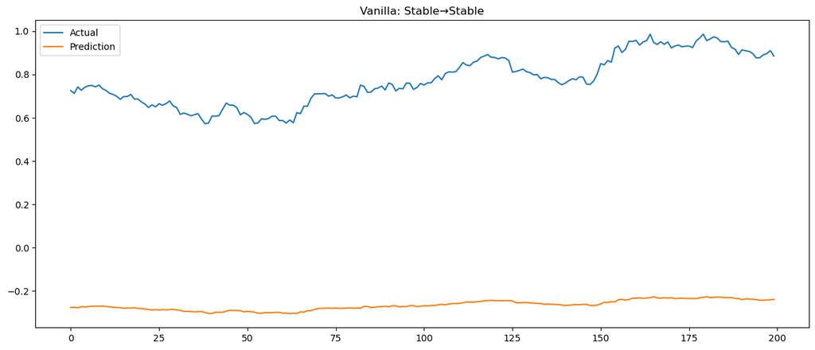

```python
plt.figure(figsize=(15,6))

plt.plot(
    actual[:200],
    label='Actual'
)

plt.plot(
    pred[:200],
    label='Prediction'
)

plt.title(
    "Vanilla: Stable→Stable"
)

plt.legend()

plt.show()
```

### Vanilla Experiment 2: (Volatile -> Volatile)

Train on volatile

```python
model_vv=train_model(
    X_volatile_train,
    y_volatile_train
)
```

Evaluate on volatile

```python
mae,mse,r2,pred,actual=\
evaluate_model(

model_vv,

X_volatile_test,

y_volatile_test
)

print(
    mae,
    mse,
    r2
)
```

```
0.536003443327817 0.2877642241817533 -459.2014928363743
```

Store results

```python
results.append({

"Model":"Vanilla",

"Train":"Volatile",

"Test":"Volatile",

"MAE":mae,

"MSE":mse,

"R2":r2
})
```

Plot

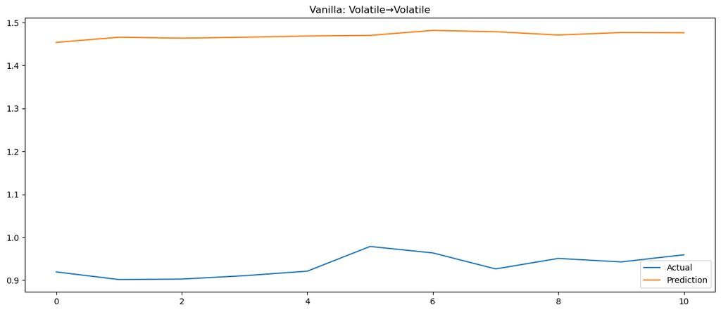

```python
plt.figure(figsize=(15,6))

plt.plot(
    actual[:200],
    label='Actual'
)

plt.plot(
    pred[:200],
    label='Prediction'
)

plt.title(
    "Vanilla: Volatile→Volatile"
)

plt.legend()

plt.show()
```

### Vanilla Experiment 3: (Stable -> Volatile)

Train on stable

```python
model_sv=train_model(

X_stable_train,

y_stable_train
)
```

Evaluate on volatile

```python
mae,mse,r2,pred,actual=\
evaluate_model(

model_sv,

X_volatile_test,

y_volatile_test
)
```

Store results

```python
results.append({

"Model":"Vanilla",

"Train":"Stable",

"Test":"Volatile",

"MAE":mae,

"MSE":mse,

"R2":r2
})
```

Plot

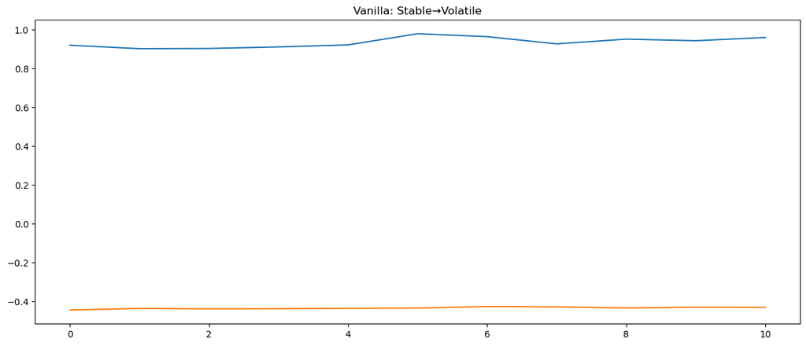

```python
plt.figure(figsize=(15,6))

plt.plot(
    actual[:200]
)

plt.plot(
    pred[:200]
)

plt.title(
    "Vanilla: Stable→Volatile"
)

plt.show()
```

### Vanilla Experiment 4: (Volatile -> Stable)

Train on volatile

```python
model_vs=train_model(

X_volatile_train,

y_volatile_train
)
```

Evaluate on stable

```python
mae,mse,r2,pred,actual=\
evaluate_model(

model_vs,

X_stable_test,

y_stable_test
)
```

Store results

```python
results.append({

"Model":"Vanilla",

"Train":"Volatile",

"Test":"Stable",

"MAE":mae,

"MSE":mse,

"R2":r2
})
```

Plot

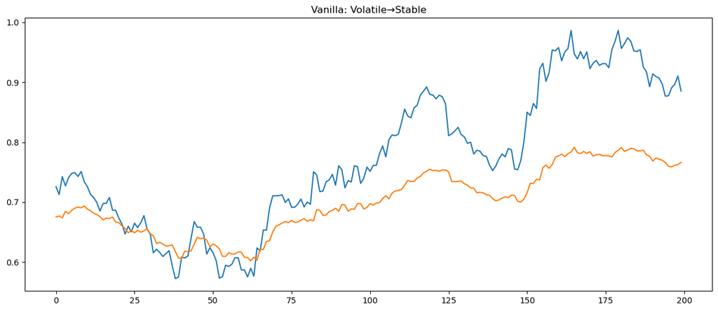

```python
plt.figure(figsize=(15,6))

plt.plot(
    actual[:200]
)

plt.plot(
    pred[:200]
)

plt.title(
    "Vanilla: Volatile→Stable"
)

plt.show()
```

### Vanilla Final Results Table

```python
results_df=pd.DataFrame(
    results
)

results_df
```

|  | Model | Train | Test | MAE | MSE | R2 |
| --- | --- | --- | --- | --- | --- | --- |
| 0 | Vanilla | Stable | Stable | 1.152300 | 1.351969 | -37.262248 |
| 1 | Vanilla | Volatile | Volatile | 0.536003 | 0.287764 | -459.201493 |
| 2 | Vanilla | Stable | Volatile | 1.369022 | 1.874733 | -2997.131549 |
| 3 | Vanilla | Volatile | Stable | 0.156193 | 0.037799 | -0.069753 |